# Common Factor Analysis

Ageev Vladimir 522

06 11 2016

```r
library(psych)
library(ggplot2)
library(GPArotation)
```

# Burritos in San Diego

Люди оценивали качество буррито в Калифорнии.

- Location – taco stand, название ларька/кафе/ресторана.
- Burrito – название буррито
- Cost – цена ($)
- Circum – “длина окружности”
- Volume – заполненность начинкой
- Tortilla – оценка качества тортильи
- Temp – оценка температуры блюда
- Meat – оценка качества мяса
- Fillings – оценка качества остальных ингридиентов
- Meat.filling – соотношение мяса и остальных ингридиентов
- Uniformity – оценка распределения мяса в буррито
- Salsa – оценка качества соуса
- Synergy – оценка вкуса
- Wrap – оценка упаковки
- overall – общая оценка блюда

142 буррито из 50 taco shops.

Подробнее про данные можно прочитать [здесь](https://srcole.github.io/100burritos/).

```r
burrito <- read.csv("/Users/Vladimir/Dropbox/Statistics_Autmn_2016/CFA/Burrito.csv")
burrito <- burrito[, c("Location", "Burrito", "Cost", "Circum", "Volume", "Tortilla", "Temp", "Meat", "Fillings", "Meat.filling", "Uniformity", "Salsa", "Synergy", "Wrap", "overall")]
burrito <- na.omit(burrito)
```

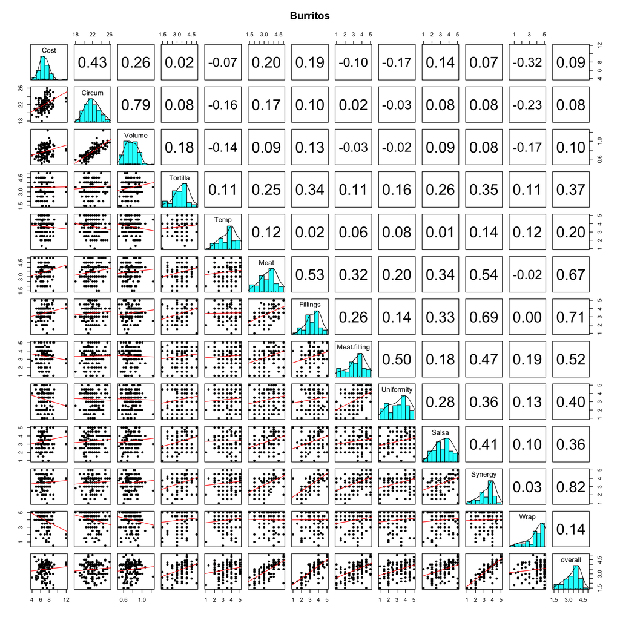

```r
burrito.scaled <- scale(burrito[,3:ncol(burrito)])
pairs.panels(burrito[,3:ncol(burrito)],
             main="Burritos", lm = TRUE, ellipses = FALSE)
```

Прологорифмируем Cost, Circum и Volume.

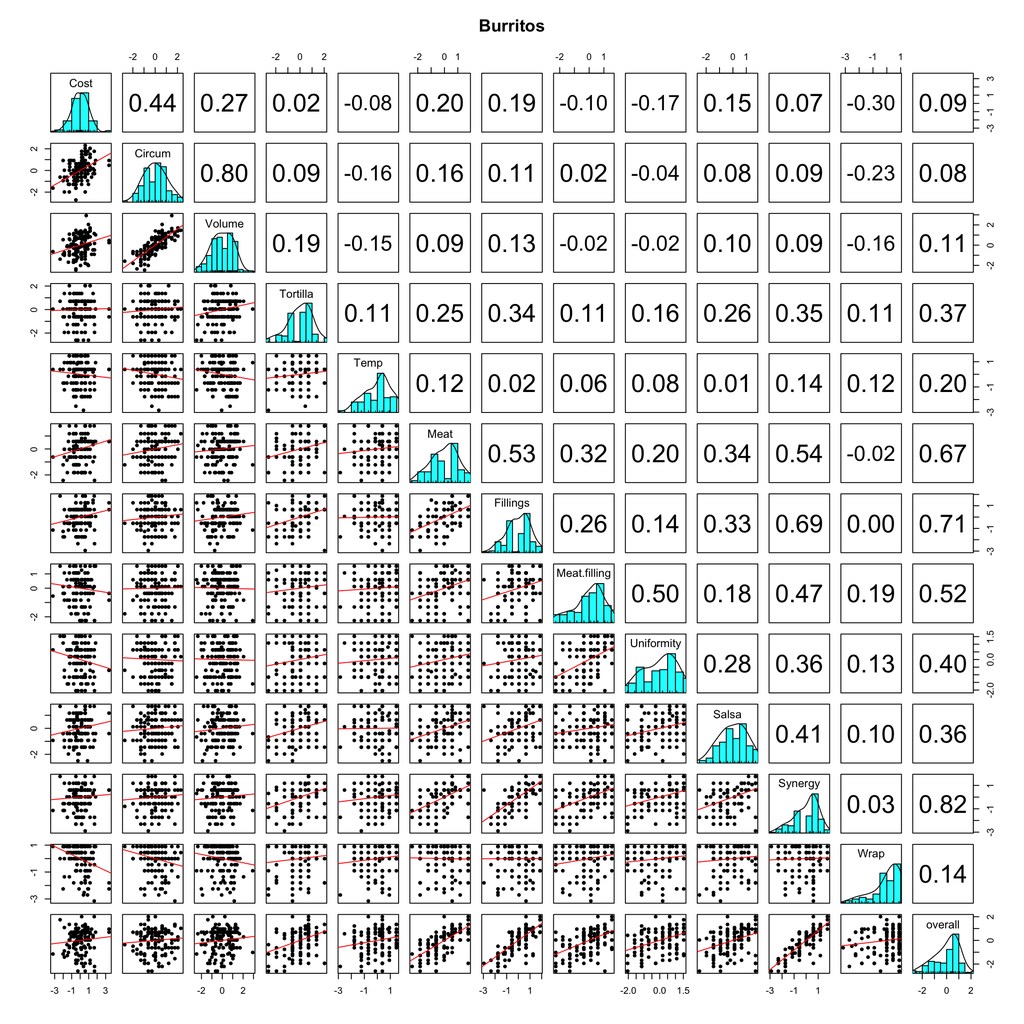

```r
burrito.loged <- burrito
burrito.loged[,3] <- log(burrito[,3])
burrito.loged[,4] <- log(burrito[,4])
burrito.loged[,5] <- log(burrito[,5])

burrito.loged.scaled <- scale(burrito.loged[,3:ncol(burrito)])

pairs.panels(burrito.loged.scaled,
             main="Burritos", lm = TRUE, ellipses = FALSE)
```

# CFA

```r
burrito.cor <- cor(burrito.loged.scaled)
```

Построим scree plot, чтобы определить необходимое число факторов. Воспользуемся “правилом сломанной трости”.

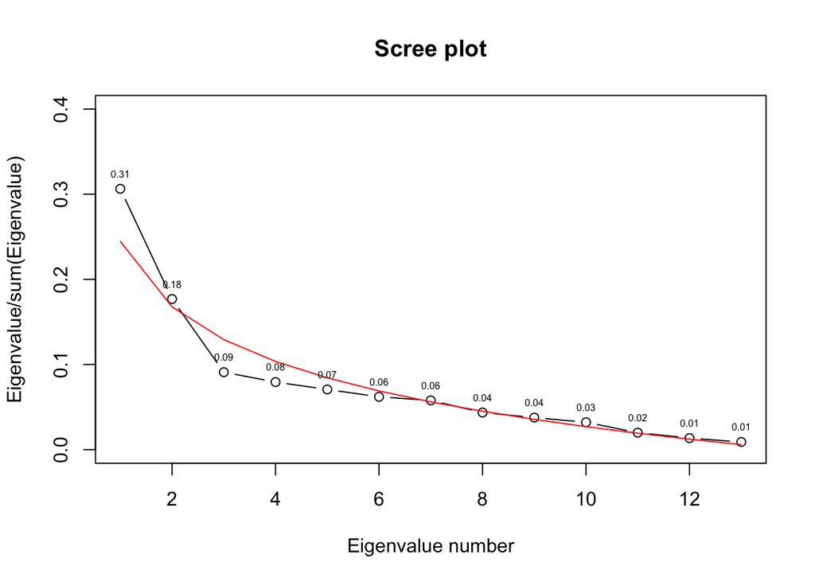

```r
eigvals <- eigen(burrito.cor)$values
EL <- sapply(1:ncol(burrito.cor), function(i){
  1/ncol(burrito.loged.scaled) * sum(1/(i:ncol(burrito.loged.scaled)))
})
plot(eigvals/ncol(burrito.loged.scaled), main = 'Scree plot',  ylab = "Eigenvalue/sum(Eigenvalue)", xlab = "Eigenvalue number", type = "b", ylim = c(0,0.4))
lines(EL, col = "red")
text(eigvals/ncol(burrito.loged.scaled), labels =  round(eigvals/ncol(burrito.loged.scaled), digits = 2), cex= 0.5, pos=3)
```

Следуя рекомендациям правила, будем искать два фактора.

## Без вращения

### FA

```r
nfac <- 2
burrito.FA.none <- fa(burrito.loged.scaled, nfactors = nfac, rotate = "none")
burrito.FA.none
```

```
## Factor Analysis using method =  minres
## Call: fa(r = burrito.loged.scaled, nfactors = nfac, rotate = "none")
## Standardized loadings (pattern matrix) based upon correlation matrix
##                MR2   MR1    h2    u2 com
## Cost          0.01  0.45 0.201 0.799 1.0
## Circum       -0.09  0.98 0.974 0.026 1.0
## Volume       -0.04  0.81 0.650 0.350 1.0
## Tortilla      0.38  0.13 0.158 0.842 1.2
## Temp          0.22 -0.15 0.068 0.932 1.8
## Meat          0.65  0.23 0.479 0.521 1.2
## Fillings      0.72  0.18 0.551 0.449 1.1
## Meat.filling  0.52  0.06 0.279 0.721 1.0
## Uniformity    0.42 -0.01 0.173 0.827 1.0
## Salsa         0.39  0.12 0.166 0.834 1.2
## Synergy       0.84  0.17 0.737 0.263 1.1
## Wrap          0.17 -0.22 0.078 0.922 1.9
## overall       0.95  0.17 0.932 0.068 1.1
##
##                        MR2  MR1
## SS loadings           3.38 2.06
## Proportion Var        0.26 0.16
## Cumulative Var        0.26 0.42
## Proportion Explained  0.62 0.38
## Cumulative Proportion 0.62 1.00
##
## Mean item complexity =  1.2
## Test of the hypothesis that 2 factors are sufficient.
##
## The degrees of freedom for the null model are  78  and the objective function was  5.56 with Chi Square of  755.6
## The degrees of freedom for the model are 53  and the objective function was  0.87
##
## The root mean square of the residuals (RMSR) is  0.07
## The df corrected root mean square of the residuals is  0.09
##
## The harmonic number of observations is  142 with the empirical chi square  111  with prob <  5.5e-06
## The total number of observations was  142  with MLE Chi Square =  116.85  with prob <  1e-06
##
## Tucker Lewis Index of factoring reliability =  0.86
## RMSEA index =  0.096  and the 90 % confidence intervals are  0.07 0.115
## BIC =  -145.81
## Fit based upon off diagonal values = 0.94
## Measures of factor score adequacy
##                                                 MR2  MR1
## Correlation of scores with factors             0.97 0.99
## Multiple R square of scores with factors       0.95 0.98
## Minimum correlation of possible factor scores  0.90 0.95
```

Первый фактор можно проинтерпретировать как удовлетворенность качеством начинки.

Второй фактор можно проинтерпретировать как удовлетворенность размерами буррито.

### Диаграмма факторных нагрузок

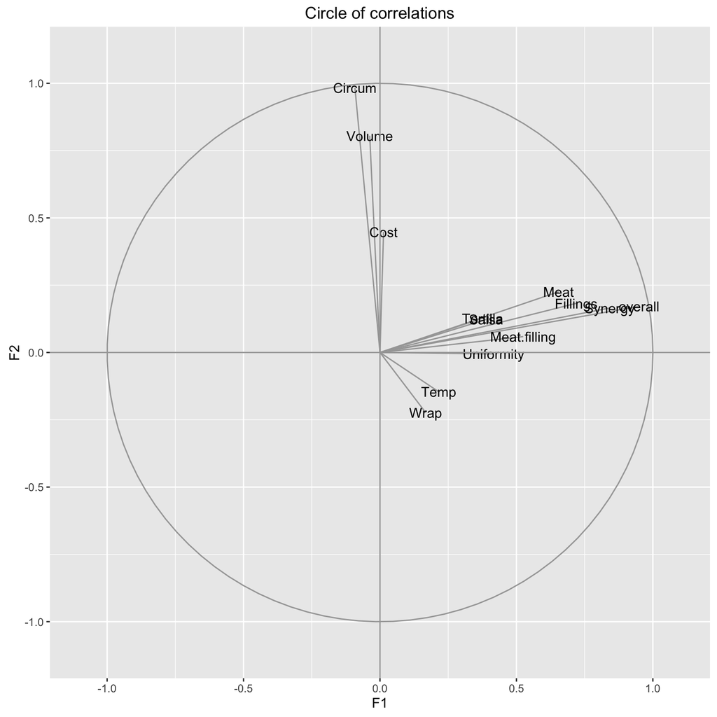

```r
# function to create a circle
circle <- function(center = c(0, 0), npoints = 100) {
    r = 1
    tt = seq(0, 2 * pi, length = npoints)
    xx = center[1] + r * cos(tt)
    yy = center[1] + r * sin(tt)
    return(data.frame(x = xx, y = yy))
}
corcir = circle(c(0, 0), npoints = 100)

# data frame with arrows coordinates
loads <- unclass(burrito.FA.none$loadings)
arrows = data.frame(x1 = rep(0, ncol(burrito.loged.scaled)), y1 = rep(0, ncol(burrito.loged.scaled)), x2 = loads[,1],
    y2 = loads[,2])

# geom_path will do open circles
ggplot() + geom_path(data = corcir, aes(x = x, y = y), colour = "gray65") +
    geom_segment(data = arrows, aes(x = x1, y = y1, xend = x2, yend = y2), colour = "gray65") +
    geom_text(data =as.data.frame(loads), aes(x = MR2, y = MR1, label = rownames(loads))) +
    geom_hline(yintercept = 0, colour = "gray65") + geom_vline(xintercept = 0,
    colour = "gray65") + xlim(-1.1, 1.1) + ylim(-1.1, 1.1) + labs(x = "F1",
    y = "F2") + ggtitle("Circle of correlations")
```

### Собственные числа в функции fa

Здесь немного отойдем в сторону от ФА и посмотрим, что выводится по $values и $e.values.

Собственные числа корреляционной матрицы:

```r
burrito.FA.none$e.values
```

```
##  [1] 3.9823297 2.2997568 1.1831211 1.0319713 0.9189812 0.8063617 0.7517885 0.5666508 0.4892140 0.4180727 0.2590224
## [12] 0.1763167 0.1164131
```

```r
eigen(burrito.cor)$values
```

```
##  [1] 3.9823297 2.2997568 1.1831211 1.0319713 0.9189812 0.8063617 0.7517885 0.5666508 0.4892140 0.4180727 0.2590224
## [12] 0.1763167 0.1164131
```

Все совпало, $e.values выдает собственные числа корреляционной матрицы.

Собственные числа $cov(\tilde{\xi})$, $\tilde{\xi} = \mathbb{F}\eta$:

```r
burrito.FA.none$values
```

```
##  [1]  3.563340801  1.917760972  0.559449496  0.240196179  0.140115326  0.096706645  0.009400127 -0.043164545
##  [9] -0.086048862 -0.155998867 -0.173760307 -0.229503135 -0.393120387
```

```r
commonCor <- burrito.cor
diag(commonCor) <- burrito.FA.none$communality
eigen(commonCor)$values
```

```
##  [1]  3.563340801  1.917760972  0.559449496  0.240196179  0.140115326  0.096706645  0.009400127 -0.043164545
##  [9] -0.086048862 -0.155998867 -0.173760307 -0.229503135 -0.393120387
```

Значения совпали.

## Varimax

```r
burrito.FA.varimax <- fa(burrito.cor, nfactors = nfac, rotate = "varimax")
burrito.FA.varimax
```

```
## Factor Analysis using method =  minres
## Call: fa(r = burrito.cor, nfactors = nfac, rotate = "varimax")
## Standardized loadings (pattern matrix) based upon correlation matrix
##               MR2   MR1    h2    u2 com
## Cost         0.10  0.44 0.201 0.799 1.1
## Circum       0.11  0.98 0.974 0.026 1.0
## Volume       0.12  0.80 0.650 0.350 1.0
## Tortilla     0.39  0.05 0.158 0.842 1.0
## Temp         0.18 -0.19 0.068 0.932 2.0
## Meat         0.69  0.09 0.479 0.521 1.0
## Fillings     0.74  0.03 0.551 0.449 1.0
## Meat.filling 0.53 -0.05 0.279 0.721 1.0
## Uniformity   0.41 -0.09 0.173 0.827 1.1
## Salsa        0.41  0.04 0.166 0.834 1.0
## Synergy      0.86 -0.01 0.737 0.263 1.0
## Wrap         0.12 -0.25 0.078 0.922 1.4
## overall      0.96 -0.02 0.932 0.068 1.0
##
##                        MR2  MR1
## SS loadings           3.54 1.91
## Proportion Var        0.27 0.15
## Cumulative Var        0.27 0.42
## Proportion Explained  0.65 0.35
## Cumulative Proportion 0.65 1.00
##
## Mean item complexity =  1.1
## Test of the hypothesis that 2 factors are sufficient.
##
## The degrees of freedom for the null model are  78  and the objective function was  5.56
## The degrees of freedom for the model are 53  and the objective function was  0.87
##
## The root mean square of the residuals (RMSR) is  0.07
## The df corrected root mean square of the residuals is  0.09
##
## Fit based upon off diagonal values = 0.94
## Measures of factor score adequacy
##                                                 MR2  MR1
## Correlation of scores with factors             0.98 0.99
## Multiple R square of scores with factors       0.95 0.97
## Minimum correlation of possible factor scores  0.90 0.95
```

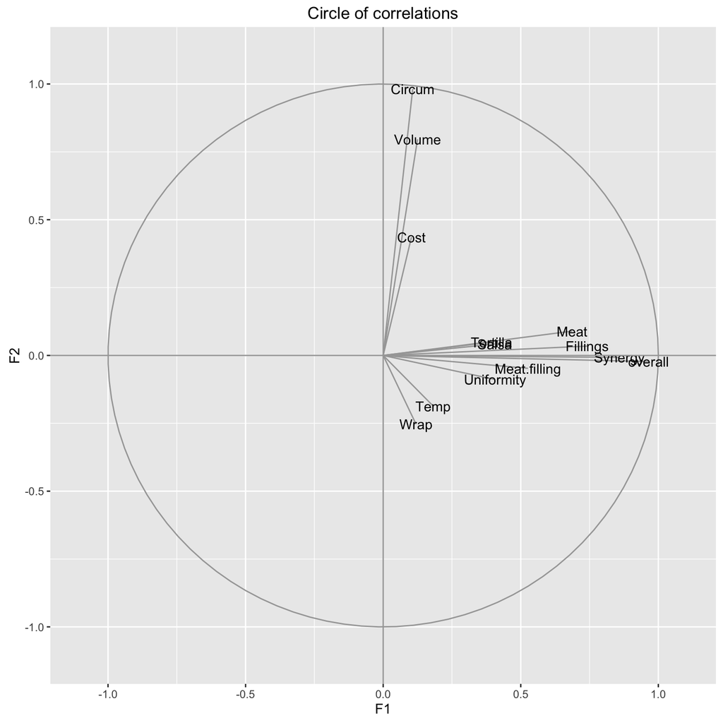

```r
corcir = circle(c(0, 0), npoints = 100)

#data frame with arrows coordinates
loads <- unclass(burrito.FA.varimax$loadings)
arrows = data.frame(x1 = rep(0, ncol(burrito.loged.scaled)), y1 = rep(0, ncol(burrito.loged.scaled)), x2 = loads[,1],
    y2 = loads[,2])

# geom_path will do open circles
ggplot() + geom_path(data = corcir, aes(x = x, y = y), colour = "gray65") +
    geom_segment(data = arrows, aes(x = x1, y = y1, xend = x2, yend = y2), colour = "gray65") +
    geom_text(data =as.data.frame(loads), aes(x = MR2, y = MR1, label = rownames(loads))) +
    geom_hline(yintercept = 0, colour = "gray65") + geom_vline(xintercept = 0,
    colour = "gray65") + xlim(-1.1, 1.1) + ylim(-1.1, 1.1) + labs(x = "F1",
    y = "F2") + ggtitle("Circle of correlations")
```

При ортогональном вращении признаки о начинке “перетянули” все на себя.

## Oblimin

### FA

```r
burrito.FA.oblimin <- fa(burrito.loged.scaled, nfactors = nfac, rotate = "oblimin")
burrito.FA.oblimin
```

```
## Factor Analysis using method =  minres
## Call: fa(r = burrito.loged.scaled, nfactors = nfac, rotate = "oblimin")
## Standardized loadings (pattern matrix) based upon correlation matrix
##                MR2   MR1    h2    u2 com
## Cost          0.05  0.44 0.201 0.799 1.0
## Circum       -0.01  0.99 0.974 0.026 1.0
## Volume        0.03  0.80 0.650 0.350 1.0
## Tortilla      0.39  0.05 0.158 0.842 1.0
## Temp          0.20 -0.19 0.068 0.932 2.0
## Meat          0.68  0.09 0.479 0.521 1.0
## Fillings      0.74  0.03 0.551 0.449 1.0
## Meat.filling  0.53 -0.05 0.279 0.721 1.0
## Uniformity    0.42 -0.09 0.173 0.827 1.1
## Salsa         0.40  0.04 0.166 0.834 1.0
## Synergy       0.86 -0.01 0.737 0.263 1.0
## Wrap          0.15 -0.26 0.078 0.922 1.6
## overall       0.97 -0.02 0.932 0.068 1.0
##
##                        MR2  MR1
## SS loadings           3.51 1.94
## Proportion Var        0.27 0.15
## Cumulative Var        0.27 0.42
## Proportion Explained  0.64 0.36
## Cumulative Proportion 0.64 1.00
##
##  With factor correlations of
##      MR2  MR1
## MR2 1.00 0.12
## MR1 0.12 1.00
##
## Mean item complexity =  1.1
## Test of the hypothesis that 2 factors are sufficient.
##
## The degrees of freedom for the null model are  78  and the objective function was  5.56 with Chi Square of  755.6
## The degrees of freedom for the model are 53  and the objective function was  0.87
##
## The root mean square of the residuals (RMSR) is  0.07
## The df corrected root mean square of the residuals is  0.09
##
## The harmonic number of observations is  142 with the empirical chi square  111  with prob <  5.5e-06
## The total number of observations was  142  with MLE Chi Square =  116.85  with prob <  1e-06
##
## Tucker Lewis Index of factoring reliability =  0.86
## RMSEA index =  0.096  and the 90 % confidence intervals are  0.07 0.115
## BIC =  -145.81
## Fit based upon off diagonal values = 0.94
## Measures of factor score adequacy
##                                                 MR2  MR1
## Correlation of scores with factors             0.98 0.99
## Multiple R square of scores with factors       0.95 0.98
## Minimum correlation of possible factor scores  0.90 0.95
```

Косоугольному вращению удалось сделать так, чтобы факторы почти не пересекались.

Посмотрим, как это выглядит на диаграмме факторных весов.

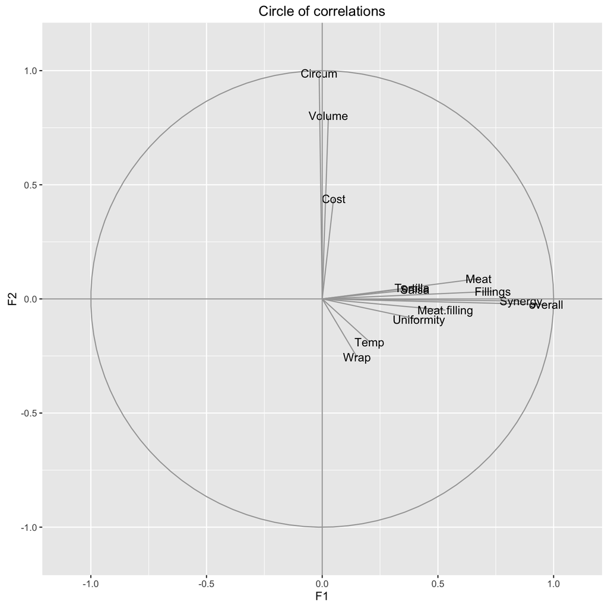

```r
corcir = circle(c(0, 0), npoints = 100)

#data frame with arrows coordinates
loads <- unclass(burrito.FA.oblimin$loadings)
arrows = data.frame(x1 = rep(0, ncol(burrito.loged.scaled)), y1 = rep(0, ncol(burrito.loged.scaled)), x2 = loads[,1],
    y2 = loads[,2])

# geom_path will do open circles
ggplot() + geom_path(data = corcir, aes(x = x, y = y), colour = "gray65") +
    geom_segment(data = arrows, aes(x = x1, y = y1, xend = x2, yend = y2), colour = "gray65") +
    geom_text(data =as.data.frame(loads), aes(x = MR2, y = MR1, label = rownames(loads))) +
    geom_hline(yintercept = 0, colour = "gray65") + geom_vline(xintercept = 0,
    colour = "gray65") + xlim(-1.1, 1.1) + ylim(-1.1, 1.1) + labs(x = "F1",
    y = "F2") + ggtitle("Circle of correlations")
```

### О корреляционных матрицах, которые можно получить из fa

Заметим, что при oblique вращении, функция вывела некую корреляционную матрицу факторов.

Покажем, что это $(\mathbf{W}^\mathrm{T}\mathbf{W})^{-1}$ – теоретическая корреляционная матрица факторов (того, что у нас обозначалось как $\eta$ на генеральном языке и $\mathbb{V}$ на выборочном) при oblique вращениях.

Phi или intercorrelation matrix:

```r
burrito.FA.oblimin$Phi
```

```
##           MR2       MR1
## MR2 1.0000000 0.1244461
## MR1 0.1244461 1.0000000
```

$(\mathbf{W}^\mathrm{T}\mathbf{W})^{-1}$

```r
solve(t(burrito.FA.oblimin$rot.mat) %*% burrito.FA.oblimin$rot.mat)
```

```
##           [,1]      [,2]
## [1,] 1.0000000 0.1244461
## [2,] 0.1244461 1.0000000
```

# Оценки factor scores

Перед тем как перейти к методам оценивания Factor Scores, приведем их желательные свойства:

- Validity — корреляция между оценками factor score и соответствующим теоретическим factor score максимальна;
- Univocality — некоррелированность оценок factor score с остальными теоретическими факторами (в случае ортогональных факторов);
- Correlation Preserving — ортогональность оценок factor scores ($cor(\hat{\mathbb{V}}) = \mathbb{I}$);
- Несмещенность

Для определения первых двух свойств строится матрица \begin{align*} \mathbb{R} = \mathbb{S}^\mathrm{T}\mathbb{W}\mathbb{L}^{-1}, \end{align*}

ее элементы — корреляции оценок factor scores с соответствующими факторами. Здесь

- $\mathbb{S} = \mathbb{F}(\mathbf{W}^\mathrm{T}\mathbf{W})^{-1}$ — Factor Structure, $\mathbf{W}$ – матрица вращения. В случае ортогонального вращения $\mathbb{S} = \mathbb{F}$;
- $\mathbb{C} = \mathbb{W}^\mathrm{T}cor(\mathbb{Y})\mathbb{W}$ — корреляционная матрица оценок factor scores, $\mathbb{W}$ — матрица “весов”, с помощью которой находятся оценки factor scores;
- $\mathbb{L} = sqrt(diag(\mathbb{C}))$ — диагональная матрица, составленная из sd оценок факторных значений.

По диагонали определяется validity, по остальным элементам – univocality.

Функция, считающая $\mathbb{R}$:

```r
scores.factor.correlation <- function(fa.object, data.cor.matrix){
  C <- t(fa.object$weights) %*% data.cor.matrix %*% fa.object$weights
  L <- (diag(C))
  L <- sqrt(L)
  L <- diag(L)
  R <- t(fa.object$Structure) %*% fa.object$weights %*% solve(L)
  return(R)
}
```

## Thurstone scores (regression method)

Здесь и далее $\hat{\mathbb{V}} = \mathbb{WY}$. \begin{align*} \mathbb{W} = cor(\mathbb{Y})^{-1} \mathbb{F} \end{align*}

Метод максимизирует корреляции между оценками factor scores и соответствующими факторами (Validity).

```r
Thurst.varimax <- fa(burrito.loged.scaled, nfactors = nfac, rotate = "varimax", scores = "Thurstone")
Thurst.oblimin <- fa(burrito.loged.scaled, nfactors = nfac, rotate = "oblimin", scores = "Thurstone")
```

Посмотрим, что за матрицы возвращает пакет.

Матрица весов:

```r
Thurst.varimax$weights
```

```
##                      MR2           MR1
## Cost         0.003580988  0.0133578335
## Circum       0.012764084  0.9362708188
## Volume       0.006085355  0.0566611530
## Tortilla     0.022737353 -0.0008668242
## Temp         0.010578706 -0.0060970978
## Meat         0.062509006 -0.0021941394
## Fillings     0.079308447 -0.0062497790
## Meat.filling 0.036006553 -0.0053390039
## Uniformity   0.024975159 -0.0052846826
## Salsa        0.023932396 -0.0011723249
## Synergy      0.158216522 -0.0169127844
## Wrap         0.007895701 -0.0078293983
## overall      0.684978075 -0.0784089167
```

Проверим, что это действительно она:

```r
solve(cor(burrito.loged.scaled)) %*% burrito.FA.varimax$loadings
```

```
##                      MR2           MR1
## Cost         0.003580988  0.0133578335
## Circum       0.012764084  0.9362708188
## Volume       0.006085355  0.0566611530
## Tortilla     0.022737353 -0.0008668242
## Temp         0.010578706 -0.0060970978
## Meat         0.062509006 -0.0021941394
## Fillings     0.079308447 -0.0062497790
## Meat.filling 0.036006553 -0.0053390039
## Uniformity   0.024975159 -0.0052846826
## Salsa        0.023932396 -0.0011723249
## Synergy      0.158216522 -0.0169127844
## Wrap         0.007895701 -0.0078293983
## overall      0.684978075 -0.0784089167
```

Корреляционная матрица оценок factor scores:

```r
Thurst.varimax$r.scores
```

```
##            MR2        MR1
## MR2 1.00000000 0.00515795
## MR1 0.00515795 1.00000000
```

```r
cor(Thurst.varimax$scores)
```

```
##            MR2        MR1
## MR2 1.00000000 0.00515795
## MR1 0.00515795 1.00000000
```

**ЗАМЕЧАНИЕ**

r.scores – корреляционная матрица оценок factor scores. fa **ВСЕГДА** считает ее исходя из оценок factor scores, полученных по regression method (Thurstone). Поэтому здесь матрица полученная вручную совпадает с r.scores, для остальных методов она **НЕ** совпадет! В справке об этом написано так:

- scores — The factor scores as requested. Note that these scores reflect the choice of the way scores should be estimated (see scores in the input). That is, simple regression (“Thurstone”), correlaton preserving (“tenBerge”) as well as “Anderson” and “Bartlett” using the appropriate algorithms (see factor.scores). **The correlation between factor score estimates (r.scores) is based upon using the regression/Thurstone approach. The actual correlation between scores will reflect the rotation algorithm chosen and may be found by correlating those scores.**

Матрица корреляций оценок factor scores с соответсвтующими факторами:

```r
scores.factor.correlation(Thurst.varimax, burrito.cor)
```

```
##            [,1]       [,2]
## MR2 0.975494245 0.00503155
## MR1 0.005092487 0.98730844
```

Oblique вращение:

```r
Thurst.oblimin$r.scores
```

```
##           [,1]      [,2]
## [1,] 1.0000000 0.1280726
## [2,] 0.1280726 1.0000000
```

```r
scores.factor.correlation(Thurst.oblimin, burrito.cor)
```

```
##          [,1]      [,2]
## MR2 0.9755056 0.1249356
## MR1 0.1265029 0.9877433
```

## Anderson scores

\begin{align*} \mathbb{W} = \mathbb{\Psi}^{-1}\mathbb{F} (\mathbb{F}^\mathrm{T} \mathbb{\Psi}^{-1} (\mathbb{F}^\mathrm{T}\mathbb{F}) \mathbb{\Psi}^{-1} \mathbb{F})^{-1/2} \end{align*}

Полученные оценки factor scores ортогональны (гарантируется только при ортогональных факторах) (Correlation preserving).

```r
Anderson.varimax <- fa(burrito.loged.scaled, nfactors = nfac, rotate = "varimax", scores = "Anderson")
Anderson.oblimin <- fa(burrito.loged.scaled, nfactors = nfac, rotate = "oblimin", scores = "Anderson")
```

Ортогональное вращение

Корреляционная матрица оценок factor scores:

```r
cor(Anderson.varimax$scores)
```

```
##               MR2           MR1
## MR2  1.000000e+00 -6.798332e-17
## MR1 -6.798332e-17  1.000000e+00
```

Матрица корреляций оценок factor scores и факторов:

```r
scores.factor.correlation(Anderson.varimax, burrito.cor)
```

```
##            [,1]        [,2]
## MR2 0.975490195 0.002529988
## MR1 0.002532117 0.987304906
```

Oblique вращение

Корреляционная матрица оценок factor scores:

```r
cor(Anderson.oblimin$scores)
```

```
##               MR2           MR1
## MR2  1.000000e+00 -1.342688e-16
## MR1 -1.342688e-16  1.000000e+00
```

Матрица корреляций оценок factor scores и факторов:

```r
scores.factor.correlation(Anderson.oblimin, burrito.cor)
```

```
##           [,1]       [,2]
## MR2 0.97495605 0.03096052
## MR1 0.09535552 0.98299571
```

## Berge scores

Расширение метода Anderson на случай неортогональных факторов.

\begin{align*} \mathbb{L} = \mathbb{F}\mathbb{\Phi}^{1/2}, \quad \mathbb{C} = cor(\mathbb{Y})^{-1/2} \mathbb{L} (\mathbb{L}^\mathrm{T} cor(\mathbb{Y})^{-1} \mathbb{L})^{-1/2}, \quad \mathbb{W} = (\mathbb{F}^\mathrm{T}\mathbb{F})^{-1/2} \mathbb{C} \mathbb{\Phi}^{1/2}, \end{align*}

где $\mathbb{\Phi}$ – common factors correlation matrix ($\mathbb{E}\mathbb{\eta\eta}^\mathrm{T}$)

```r
Berge.varimax <- fa(burrito.loged.scaled, nfactors = nfac, rotate = "varimax", scores = "tenBerge")
Berge.oblimin <- fa(burrito.loged.scaled, nfactors = nfac, rotate = "oblimin", scores = "tenBerge")
```

Ортогональное вращение

Корреляционная матрица оценок factor scores:

```r
cor(Berge.varimax$scores)
```

```
##               MR2           MR1
## MR2  1.000000e+00 -1.059282e-14
## MR1 -1.059282e-14  1.000000e+00
```

Матрица корреляций оценок factor scores и факторов:

```r
scores.factor.correlation(Berge.varimax, burrito.cor)
```

```
##            [,1]        [,2]
## MR2 0.975490962 0.002530926
## MR1 0.002530926 0.987305201
```

Oblique вращение

Корреляционная матрица оценок factor scores:

```r
cor(Berge.oblimin$scores)
```

```
##              MR2          MR1
## MR2 1.000000e+00 1.230912e-15
## MR1 1.230912e-15 1.000000e+00
```

Матрица корреляций оценок factor scores и факторов:

```r
scores.factor.correlation(Berge.oblimin, burrito.cor)
```

```
##           [,1]       [,2]
## MR2 0.97346998 0.06298698
## MR1 0.06298698 0.98573299
```

## Bartlett scores (WLS)

\begin{align*} \mathbb{W} = \mathbb{\Psi}^{-1}\mathbb{F} (\mathbb{F}^\mathrm{T} \mathbb{\Psi}^{-1}\mathbb{F})^{-1}. \end{align*}

В отличие от остальных методов (кроме Harman), получаем несмещенные оценки, коррелирующие только с соответствующими факторами (Univocality).

```r
Bartlett.varimax <- fa(burrito.loged.scaled, nfactors = nfac, rotate = "varimax", scores = "Bartlett")
Bartlett.oblimin <- fa(burrito.loged.scaled, nfactors = nfac, rotate = "oblimin", scores = "Bartlett")
```

Ортогональное вращение

Корреляционная матрица оценок factor scores:

```r
cor(Bartlett.varimax$scores)
```

```
##              MR2          MR1
## MR2  1.000000000 -0.005158197
## MR1 -0.005158197  1.000000000
```

Матрица корреляций оценок factor scores и факторов:

```r
scores.factor.correlation(Bartlett.varimax, burrito.cor)
```

```
##             [,1]          [,2]
## MR2 9.754805e-01 -4.110441e-17
## MR1 3.722816e-17  9.872950e-01
```

Корреляции оценок factor scores с несоответствующими факторами нулевые (Univocality).

Oblique вращение

Корреляционная матрица оценок factor scores:

```r
cor(Bartlett.oblimin$scores)
```

```
##            MR2        MR1
## MR2  1.0000000 -0.1280947
## MR1 -0.1280947  1.0000000
```

Матрица корреляций оценок factor scores и факторов:

```r
scores.factor.correlation(Bartlett.oblimin, burrito.cor)
```

```
##             [,1]      [,2]
## MR2 9.674117e-01 0.0000000
## MR1 4.027660e-17 0.9794739
```

Корреляции оценок factor scores с несоответствующими факторами нулевые (Univocality).

## Harman scores (OLS)

\begin{align*} \mathbb{W} = \mathbb{F} (\mathbb{F}^\mathrm{T} \mathbb{F})^{-1} \end{align*}

Как и в случае Brtlett, получаем несмещенные оценки, коррелирующие только с соответствующими факторами (Univocality).

```r
Harman.varimax <- fa(burrito.loged.scaled, nfactors = nfac, rotate = "varimax", scores = "Harman")
Harman.oblimin <- fa(burrito.loged.scaled, nfactors = nfac, rotate = "oblimin", scores = "Harman")
```

Ортогональное вращение

Корреляционная матрица оценок factor scores:

```r
cor(Harman.varimax$scores)
```

```
##             MR2         MR1
## MR2  1.00000000 -0.01648406
## MR1 -0.01648406  1.00000000
```

Матрица корреляций factor scores и факторов:

```r
scores.factor.correlation(Harman.varimax, burrito.cor)
```

```
##             [,1]         [,2]
## MR2 9.477769e-01 6.472071e-18
## MR1 2.712816e-17 9.327238e-01
```

Корреляции оценок factor scores с несоответствующими факторами нулевые (Univocality).

Oblique вращение

Корреляционная матрица оценок factor scores:

```r
cor(Harman.oblimin$scores)
```

```
##            MR2        MR1
## MR2  1.0000000 -0.1424201
## MR1 -0.1424201  1.0000000
```

Матрица корреляций оценок factor scores и факторов:

```r
scores.factor.correlation(Harman.oblimin, burrito.cor)
```

```
##             [,1]         [,2]
## MR2 9.382767e-01 2.568612e-17
## MR1 3.255301e-18 9.254399e-01
```

Корреляции оценок factor scores с несоответствующими факторами нулевые (Univocality).